# EDA tennis

Gabriela Orłowska

2023-11-24

### Wstęp

Turnieje wielkoszlemowe w tenisie to największe i najważniejsze zawody na świecie. Cztery turnieje, które odbywają się każdego roku, nieustannie biją rekordy finansowe i przyciągają coraz większą liczbę kibiców. Największe emocje zawsze towarzyszą turniejom mężczyzn w grze pojedynczej. Dla każdego początkującego tenisisty marzeniem jest zdobycie tytułu wielkoszlemowego i wpisanie się w historię światowego tenisa. Tradycyjnie, turnieje odbywają się co roku w następujących miejscach i terminach: 1. Australian Open (styczeń, Melbourne) 2. French Open (maj/czerwiec, Paryż) 3. Wimbledon (lipiec, Londyn) 4. US Open (sierpień/wrzesień, Nowy Jork). Obecnie turnieje: w Australii i USA są rozgrywane na nawierzchni twardej, w Paryżu na kortach ziemnych, a Wimbledon na trawie. Zwycięzca turnieju wielkoszlemowego otrzymuje 2000 punktów do rankingu ATP. To właśnie te imprezy decydują o najwyższych osiągnięciach w karierze tenisowej.

### Zmienne:

1. **YEAR** (liczbowo - lata)
2. **TOURNAMENT**(tekst - nazwy turniejów)
3. **WINNER** (tekst - imię i nazwisko zwycięzcy)
4. **RUNNER UP** (tekst - imię i nazwisko przegranego w finale)
5. **WINNER NATIONALITY** (tekst - narodowość wygranego)
6. **WINNER ATP RANKING** (liczbowo, ranking zwycięzcy, po 2007 roku)
7. **RUNNER UP ATP_RANKING** (liczbowo, ranking przegranego, po 2007 roku)
8. **WINNER LEFT OR RIGHT HANDED** (tekst, right - praworęczny, left - leworęczny)
9. **TOURNAMENT SURFACE** (tekst - rodzaj nawierzchni)
10. **WINNER PRIZE** (liczba - w lokalnej walucie, US Open(USD), Australian Open(AUD), French Open(FRF do 2001, EUR od 2002), Wimbledon(GBP))

#### Pakiety, których będę używała

```r
library(dplyr)
library(psych)
library(ggplot2)
library(mice)
library(tidyr)
library(gmodels)
library(gridExtra)
```

Wczytuję zestaw danych do R:

```r
dane <- read.csv("C:\\Users\\user\\OneDrive\\Pulpit\\Mens_Tennis_Grand_Slam_Winner.csv")
```

Zapoznaję się z zestawem danych:

```r
head(dane, 5)
```

```
##   YEAR      TOURNAMENT         WINNER          RUNNER.UP WINNER_NATIONALITY
## 1 2023 Australian Open Novak Djokovic Stefanos Tsitsipas            Serbian
## 2 2022       U.S. Open Carlos Alcaraz        Casper Rudd            Spanish
## 3 2022       Wimbledon Novak Djokovic       Nick Kyrgios            Serbian
## 4 2022     French Open   Rafael Nadal        Casper Rudd            Spanish
## 5 2022 Australian Open   Rafael Nadal    Daniil Medvedev            Spanish
##   WINNER_ATP_RANKING RUNNER.UP_ATP_RANKING WINNER_LEFT_OR_RIGHT_HANDED
## 1                  1                     3                       right
## 2                  2                     5                       right
## 3                  3                    25                       right
## 4                  5                     8                        left
## 5                  5                     2                        left
##      TOURNAMENT_SURFACE WINNER_PRIZE
## 1 Plexicushion Prestige      2050000
## 2   DecoTurf - outdoors      2600000
## 3       Grass / Outdoor      2507460
## 4                  Clay      1870000
## 5 Plexicushion Prestige      4400000
```

```r
tail(dane, 5)
```

```
##     YEAR      TOURNAMENT        WINNER       RUNNER.UP WINNER_NATIONALITY
## 288 1951 Australian Open   Dick Savitt    Ken McGregor           American
## 289 1950       U.S. Open Arthur Larsen    Herbert Flam           American
## 290 1950       Wimbledon    J.E. Patty   Frank Sedgman           American
## 291 1950     French Open   Budge Patty Jaroslav Drobny           American
## 292 1950 Australian Open Frank Sedgman    Ken McGregor         Australian
##     WINNER_ATP_RANKING RUNNER.UP_ATP_RANKING WINNER_LEFT_OR_RIGHT_HANDED
## 288                 NA                    NA                       right
## 289                 NA                    NA                       right
## 290                 NA                    NA                       right
## 291                 NA                    NA                       right
## 292                 NA                    NA                       right
##     TOURNAMENT_SURFACE WINNER_PRIZE
## 288              Grass           NA
## 289           outdoors           NA
## 290    Grass / Outdoor           NA
## 291               Clay           NA
## 292              Grass           NA
```

W wybranym przeze mnie zestawie danych w kolumnie `TOURNAMENT_SURFACE` pojawiają się nazwy nawierzchni, na których rozgrywane są poszczególne turnieje. Jednakże, zauważam, że te nazwy są zbyt szczegółowe. W celu ułatwienia analizy i zrozumienia tego zestawu danych, dokonuję zmiany na trzy podstawowe nazwy nawierzchni (hard, caly, grass), zgodnie ze zmianami, jakie zachodziły w przeszłości.

```r
dane$TOURNAMENT_SURFACE[dane$YEAR <= 1987 & dane$TOURNAMENT == "Australian Open"] <- "Grass"
dane$TOURNAMENT_SURFACE[dane$YEAR > 1987 & dane$TOURNAMENT == "Australian Open"] <- "Hard"
dane$TOURNAMENT_SURFACE[dane$YEAR <= 1974 & dane$TOURNAMENT == "U.S. Open"] <- "Grass"
dane$TOURNAMENT_SURFACE[dane$YEAR > 1974 & dane$YEAR <= 1977 & dane$TOURNAMENT == "U.S. Open"] <- "Clay"
dane$TOURNAMENT_SURFACE[dane$YEAR >= 1978 & dane$TOURNAMENT == "U.S. Open"] <- "Hard"
dane$TOURNAMENT_SURFACE[dane$TOURNAMENT == "Wimbledon"] <- "Grass"
dane$TOURNAMENT_SURFACE[dane$TOURNAMENT == "French Open" | dane$TOURNAMENT == "Roland Garros"] <- "Clay"
```

Uzupełniam dane, ponieważ wszystkie turnieje wielkoszlemowe w 2023 roku zostały już rozgrane.

```r
uzupełnienie_danych <- data.frame(
  YEAR = c(2023, 2023, 2023),
  TOURNAMENT = c("U.S. Open", "Wimbledon", "French Open"),
  WINNER = c("Novak Djokovic", "Carlos Alcaraz", "Novak Djokovic"),
  RUNNER.UP = c("Daniil Medvedev", "Novak Djokovic", "Casper Ruud"),
  WINNER_NATIONALITY = c("Serbian", "Spanish", "Serbian"),
  WINNER_ATP_RANKING = c(2, 1, 3),
  RUNNER.UP_ATP_RANKING = c(3, 2, 4),
  WINNER_LEFT_OR_RIGHT_HANDED = c("right", "right", "right"),
  TOURNAMENT_SURFACE = c("Hard", "Grass", "Clay"),
  WINNER_PRIZE = c(3000000, 2350000, 2300000)
)
dane <- rbind(uzupełnienie_danych, dane)
```

Sprawdzam strukturę pliku:

```r
str(dane)
```

```
## 'data.frame':    295 obs. of  10 variables:
##  $ YEAR                       : num  2023 2023 2023 2023 2022 ...
##  $ TOURNAMENT                 : chr  "U.S. Open" "Wimbledon" "French Open" "Australian Open" ...
##  $ WINNER                     : chr  "Novak Djokovic" "Carlos Alcaraz" "Novak Djokovic" "Novak Djokovic" ...
##  $ RUNNER.UP                  : chr  "Daniil Medvedev" "Novak Djokovic" "Casper Ruud" "Stefanos Tsitsipas" ...
##  $ WINNER_NATIONALITY         : chr  "Serbian" "Spanish" "Serbian" "Serbian" ...
##  $ WINNER_ATP_RANKING         : num  2 1 3 1 2 3 5 5 2 1 ...
##  $ RUNNER.UP_ATP_RANKING      : num  3 2 4 3 5 25 8 2 1 7 ...
##  $ WINNER_LEFT_OR_RIGHT_HANDED: chr  "right" "right" "right" "right" ...
##  $ TOURNAMENT_SURFACE         : chr  "Hard" "Grass" "Clay" "Hard" ...
##  $ WINNER_PRIZE               : num  3000000 2350000 2300000 2050000 2600000 ...
```

```r
dim(dane)
```

```
## [1] 295  10
```

```r
class(dane)
```

```
## [1] "data.frame"
```

Można spodziewać się, że w niektórych zmiennych pojawiają się braki danych. Potwierdzam to za pomocą funkcji `md.pattern()`:

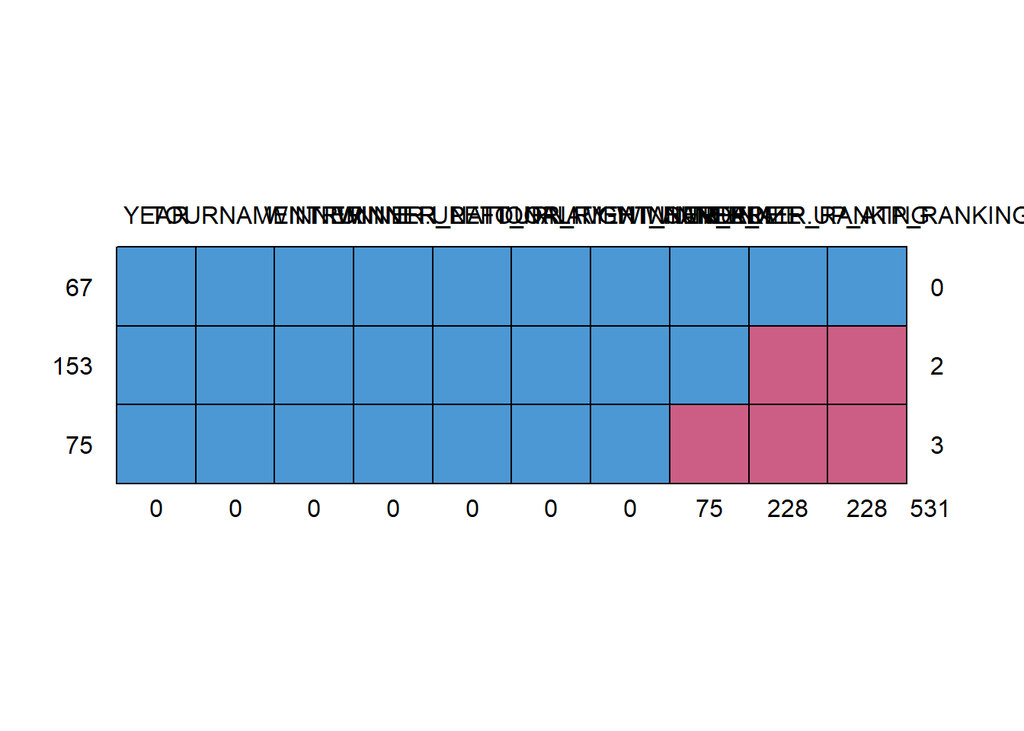

```
##     YEAR TOURNAMENT WINNER RUNNER.UP WINNER_NATIONALITY
## 67     1          1      1         1                  1
## 153    1          1      1         1                  1
## 75     1          1      1         1                  1
##        0          0      0         0                  0
##     WINNER_LEFT_OR_RIGHT_HANDED TOURNAMENT_SURFACE WINNER_PRIZE
## 67                            1                  1            1
## 153                           1                  1            1
## 75                            1                  1            0
##                               0                  0           75
##     WINNER_ATP_RANKING RUNNER.UP_ATP_RANKING
## 67                   1                     1   0
## 153                  0                     0   2
## 75                   0                     0   3
##                    228                   228 531
```

```r
md.pattern(dane)
```

Najwięcej braków danych (aż 228) jest w zmiennych: `WINNER_ATP_RANKING` i `RUNNER_UP_ATP_RANKING`, ponieważ te dane pojawiają się dopiero od 2007 roku. Decyduję, że usunę te zmienne z mojego zestawu (nie będą mi potrzebne w póżniejszej analizie).

```r
dane <- dane[, !(names(dane) %in% c("WINNER_ATP_RANKING", "RUNNER.UP_ATP_RANKING"))]
head(dane)
```

```
##   YEAR      TOURNAMENT         WINNER          RUNNER.UP WINNER_NATIONALITY
## 1 2023       U.S. Open Novak Djokovic    Daniil Medvedev            Serbian
## 2 2023       Wimbledon Carlos Alcaraz     Novak Djokovic            Spanish
## 3 2023     French Open Novak Djokovic        Casper Ruud            Serbian
## 4 2023 Australian Open Novak Djokovic Stefanos Tsitsipas            Serbian
## 5 2022       U.S. Open Carlos Alcaraz        Casper Rudd            Spanish
## 6 2022       Wimbledon Novak Djokovic       Nick Kyrgios            Serbian
##   WINNER_LEFT_OR_RIGHT_HANDED TOURNAMENT_SURFACE WINNER_PRIZE
## 1                       right               Hard      3000000
## 2                       right              Grass      2350000
## 3                       right               Clay      2300000
## 4                       right               Hard      2050000
## 5                       right               Hard      2600000
## 6                       right              Grass      2507460
```

Wyznaczam statystyki opisowe:

```r
summary(dane)
```

```
##       YEAR       TOURNAMENT           WINNER           RUNNER.UP
##  Min.   :1950   Length:295         Length:295         Length:295
##  1st Qu.:1968   Class :character   Class :character   Class :character
##  Median :1986   Mode  :character   Mode  :character   Mode  :character
##  Mean   :1986
##  3rd Qu.:2005
##  Max.   :2023
##
##  WINNER_NATIONALITY WINNER_LEFT_OR_RIGHT_HANDED TOURNAMENT_SURFACE
##  Length:295         Length:295                  Length:295
##  Class :character   Class :character            Class :character
##  Mode  :character   Mode  :character            Mode  :character
##
##
##
##
##   WINNER_PRIZE
##  Min.   :   2000
##  1st Qu.: 104719
##  Median : 622500
##  Mean   :1080224
##  3rd Qu.:1767848
##  Max.   :4538000
##  NA's   :75
```

```r
dane %>%
  select(YEAR, WINNER_PRIZE) %>%
  describe()
```

```
##              vars   n       mean         sd median   trimmed       mad  min
## YEAR            1 295    1986.36      21.35   1986   1986.34     26.69 1950
## WINNER_PRIZE    2 220 1080224.31 1170249.20 622500 887496.93 863614.50 2000
##                  max   range skew kurtosis       se
## YEAR            2023      73 0.01    -1.21     1.24
## WINNER_PRIZE 4538000 4536000 1.14     0.33 78898.18
```

Przyglądam się zmiennym:

```r
table(dane$TOURNAMENT)
```

```
##
## Australian Open     French Open       U.S. Open       Wimbledon
##              74              74              74              73
```

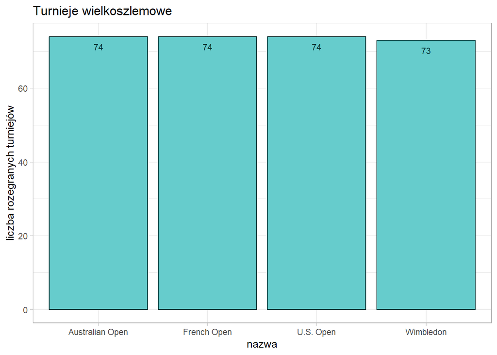

```r
dane %>%
  ggplot() +
  geom_bar(aes(x = TOURNAMENT),
           color = "#003333", fill = "#66cccc") +
  geom_text(stat = "count", aes(x = TOURNAMENT, label = stat(count)),
            vjust = 2, size = 3, color = "#003333") +
  theme_light() +
  labs(title = "Turnieje wielkoszlemowe",
       x = "nazwa",
       y = "liczba rozegranych turniejów")
```

Turnieje: Australian Open, French Open, U.S. Open zostały rozegrane 74 razy. Natomiast Wimbledon 73 razy, ponieważ w 2020 roku z powodu pandemi COVID nie odbył się.

Przyglądam się zmiennej `WINNER`. Spodziewam się różnorodności nazwisk, więc sprawdzam ich liczbę. To samo robię ze zmienną `RUNNER.UP`.

```r
winner_length <- length(unique(dane$WINNER))
runnerup_length <- length(unique(dane$RUNNER.UP))
cat("Winner:", winner_length, "Runner up:", runnerup_length, "\n")
```

```
## Winner: 83 Runner up: 133
```

Zmienna `RUNNER.UP`jest bardziej zróznicowana od zmiennej `WINNER`.

```r
table(dane$WINNER_NATIONALITY)
```

```
##
##       American      Argentine     Australian       Austrian      Brazilian
##             67              6             67              2              3
##        British       Croatian          Czech   Czechoslovak Czechoslovakia
##              3              2              4              3              8
##          Dutch     Ecuadorian         French         German        Italian
##              1              1              1              7              3
##        Mexican       peruvian       Romanian        Russian        Serbian
##              1              2              2              5             24
##        Spanish        Swedish          Swiss
##             34             26             23
```

```r
dane$WINNER_NATIONALITY[dane$WINNER_NATIONALITY == "Czechoslovak"] <- "Czechoslovakia"
narodowosci <- dane %>%
  group_by(WINNER_NATIONALITY) %>%
  summarise(count = n()) %>%
  arrange(desc(count)) %>%
  head(10)

print(narodowosci)
```

```
## # A tibble: 10 × 2
##    WINNER_NATIONALITY count
##    <chr>              <int>
##  1 American              67
##  2 Australian            67
##  3 Spanish               34
##  4 Swedish               26
##  5 Serbian               24
##  6 Swiss                 23
##  7 Czechoslovakia        11
##  8 German                 7
##  9 Argentine              6
## 10 Russian                5
```

Najwięcej zwycięzców pochodziło z Australii i USA - aż 67 osób.

```r
table(dane$WINNER_LEFT_OR_RIGHT_HANDED)
```

```
##
##  left right
##    65   230
```

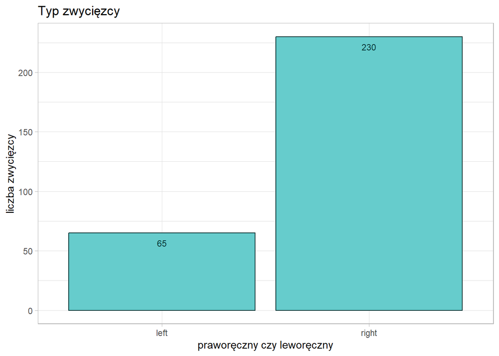

```r
dane %>%
  ggplot() +
  geom_bar(aes(x = WINNER_LEFT_OR_RIGHT_HANDED),
           color = "#003333", fill = "#66cccc") +
  geom_text(stat = "count", aes(x = WINNER_LEFT_OR_RIGHT_HANDED , label = stat(count)),
            vjust = 2, size = 3, color = "#003333") +
  theme_light() +
  labs(title = "Typ zwycięzcy",
       x = "praworęczny czy leworęczny",
       y = "liczba zwycięzcy")
```

Wśród zwycięzców dominują zawodnicy praworęczni.

```r
table(dane$TOURNAMENT_SURFACE)
```

```
##
##  Clay Grass  Hard
##    77   136    82
```

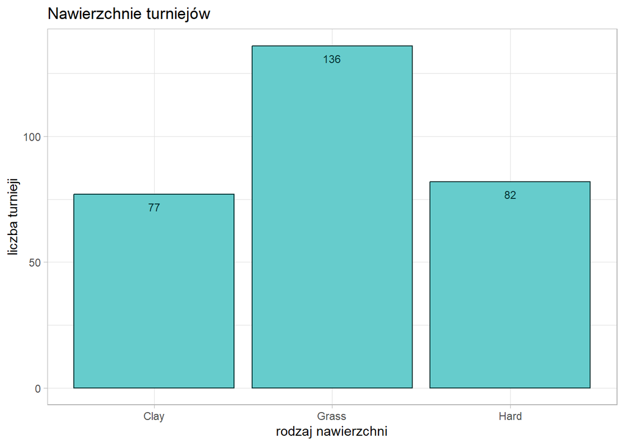

```r
dane %>%
  ggplot() +
  geom_bar(aes(x = TOURNAMENT_SURFACE),
           color = "#003333", fill = "#66cccc") +
  geom_text(stat = "count", aes(x = TOURNAMENT_SURFACE , label = stat(count)),
            vjust = 2, size = 3, color = "#003333") +
  theme_light() +
  labs(title = "Nawierzchnie turniejów",
       x = "rodzaj nawierzchni",
       y = "liczba turnieji")
```

Najwięcej turniejów zostało rozegranych na trawie. Jednak w przyszłości te proporcje ulegną zmianie, ponieważ tylko jeden turniej wielkoszlemowy pozostał z nawierzchnią trawiastą.

## 1

*Czy “BIG 3” (Novak Djokovic, Rafael Nadal i Roger Federer) zdominowali męski tenis?* Sprawdzę to za pomocą wykresu słupkowego, który będzie przedstawiać liczbę zwycięstw, liczbę udziałów w finałach oraz ich sumę. Najpierw muszę przygotować dane, aby narysować ten wykres.

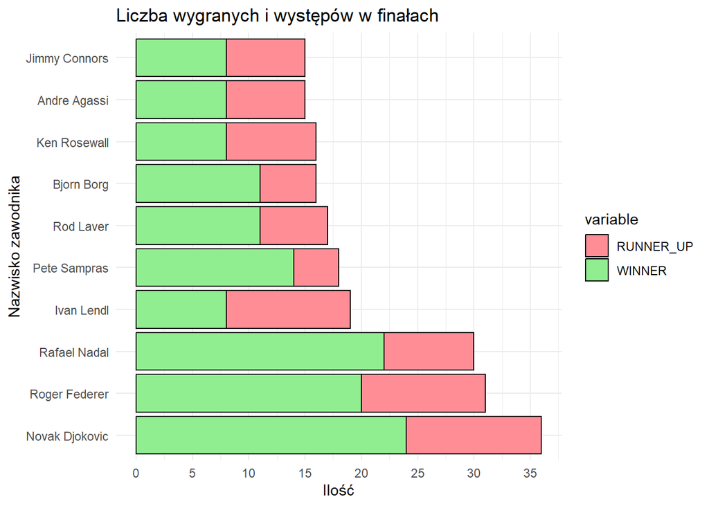

```r
runner_up_counts <- table(dane$RUNNER.UP)
winner_counts <- table(dane$WINNER)
winner_runner_merged <- merge(data.frame(Player = names(runner_up_counts), RUNNER_UP = as.vector(runner_up_counts)),
                              data.frame(Player = names(winner_counts), WINNER = as.vector(winner_counts)),
                              by = 'Player')
winner_runner_merged <- winner_runner_merged[order(-(winner_runner_merged$RUNNER_UP + winner_runner_merged$WINNER)),]
win <- head(winner_runner_merged, 10)
win$RUNNER_UP <- as.integer(win$RUNNER_UP)
win$WINNER <- as.integer(win$WINNER)
melted_win <- pivot_longer(win, cols = c("RUNNER_UP", "WINNER"), names_to = "variable", values_to = "value")
ggplot(melted_win, aes(y = factor(Player, levels = win$Player), x = value, fill = variable)) +
  geom_bar(stat = "identity", colour = "black", position = "stack") +
  scale_fill_manual(values = c("WINNER" = "lightgreen", "RUNNER_UP" = "#ff8d96")) +
  labs(title = 'Liczba wygranych i występów w finałach',
       y = "Nazwisko zawodnika",
       x = "Ilość") +
  theme_minimal() +
  theme(axis.ticks.y = element_blank())+
  scale_x_continuous(breaks = seq(0, 35, by = 5))
```

Jak możemy zauważyć na powyższym wykresie, zawodnicy z “BIG 3” mają dużą przewagę zarówno w liczbie wygranych turniejów wielkoszlemowych oraz liczbie udziałów w finałach nad pozostałymi zwycięzcami wielkoszlemowymi. Novak Djokovic (24 wygrane) i Rafael Nadal (22 wygrane) mogą jeszcze zwiększyć tę przewagę; Roger Federer (20 wygranych) już tego nie zrobi, ponieważ zakończył karierę w 2022 roku.

## 2

*Czy istnieje zależność pomiędzy wygranymi turniejami przez Rafaela Nadala - wiele osób nazywa go królem mączki (clay), a nawierzchnią turnieju?*

```r
chi_square_test <- CrossTable(dane$TOURNAMENT_SURFACE, dane$WINNER == "Rafael Nadal", fisher = T)
```

```
##
##
##    Cell Contents
## |-------------------------|
## |                       N |
## | Chi-square contribution |
## |           N / Row Total |
## |           N / Col Total |
## |         N / Table Total |
## |-------------------------|
##
##
## Total Observations in Table:  295
##
##
##                         | dane$WINNER == "Rafael Nadal"
## dane$TOURNAMENT_SURFACE |     FALSE |      TRUE | Row Total |
## ------------------------|-----------|-----------|-----------|
##                    Clay |        63 |        14 |        77 |
##                         |     0.957 |    11.875 |           |
##                         |     0.818 |     0.182 |     0.261 |
##                         |     0.231 |     0.636 |           |
##                         |     0.214 |     0.047 |           |
## ------------------------|-----------|-----------|-----------|
##                   Grass |       134 |         2 |       136 |
##                         |     0.527 |     6.537 |           |
##                         |     0.985 |     0.015 |     0.461 |
##                         |     0.491 |     0.091 |           |
##                         |     0.454 |     0.007 |           |
## ------------------------|-----------|-----------|-----------|
##                    Hard |        76 |         6 |        82 |
##                         |     0.000 |     0.002 |           |
##                         |     0.927 |     0.073 |     0.278 |
##                         |     0.278 |     0.273 |           |
##                         |     0.258 |     0.020 |           |
## ------------------------|-----------|-----------|-----------|
##            Column Total |       273 |        22 |       295 |
##                         |     0.925 |     0.075 |           |
## ------------------------|-----------|-----------|-----------|
##
##
## Fisher's Exact Test for Count Data
## ------------------------------------------------------------
## Alternative hypothesis: two.sided
## p =  4.247224e-05
##
##
```

```r
print(chi_square_test)
```

```
## $t
##        y
## x       FALSE TRUE
##   Clay     63   14
##   Grass   134    2
##   Hard     76    6
##
## $prop.row
##        y
## x            FALSE       TRUE
##   Clay  0.81818182 0.18181818
##   Grass 0.98529412 0.01470588
##   Hard  0.92682927 0.07317073
##
## $prop.col
##        y
## x            FALSE       TRUE
##   Clay  0.23076923 0.63636364
##   Grass 0.49084249 0.09090909
##   Hard  0.27838828 0.27272727
##
## $prop.tbl
##        y
## x             FALSE        TRUE
##   Clay  0.213559322 0.047457627
##   Grass 0.454237288 0.006779661
##   Hard  0.257627119 0.020338983
##
## $fisher.ts
##
##  Fisher's Exact Test for Count Data
##
## data:  t
## p-value = 4.247e-05
## alternative hypothesis: two.sided
```

Wyniki testu chi-kwadrat oraz testu Fishera wskazują na potencjalną istotną zależność między rodzajem nawierzchni turnieju a tym, czy Rafael Nadal wygrał czy nie. Każda komórka w tabeli przedstawia liczbę obserwacji dla konkretnej kombinacji nawierzchni turnieju i zwycięstwa Rafaela Nadala. Na przykład na nawierzchni “Clay” są 63 przypadki, gdy Rafael Nadal nie wygrał, i 14 przypadków, gdy zwyciężył. Statystyka chi-kwadrat oraz test Fishera sugerują, że nawierzchnia “Clay” wnosi istotny wkład do tych statystyk, co może wskazywać na zależność między rodzajem nawierzchni a statusem zwycięstwa Rafaela Nadala. Wartość p (p-value) dla testu Fishera wynosi 4.247e-05, co jest znacząco poniżej standardowego poziomu istotności 0.05. Oznacza to, że istnieją istotne różnice między grupami, potwierdzając potencjalną zależność między badanymi zmiennymi. Również potwierdza to poniższy wykres:

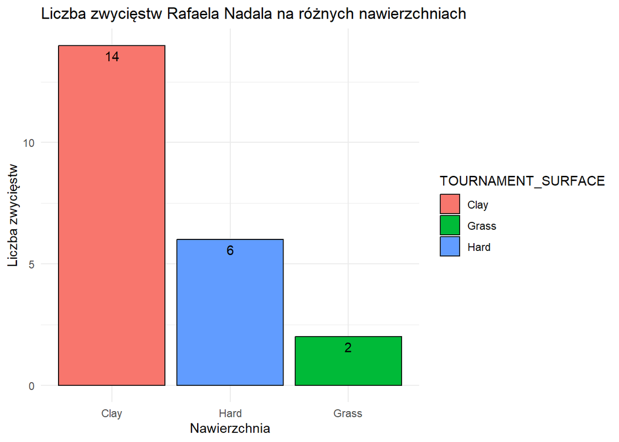

```r
dane_Nadal <- dane %>%
  filter(WINNER == "Rafael Nadal") %>%
  group_by(TOURNAMENT_SURFACE) %>%
  summarise(Wins = n()) %>%
  arrange(desc(Wins))

ggplot(dane_Nadal, aes(x = reorder(TOURNAMENT_SURFACE, -Wins), y = Wins, fill = TOURNAMENT_SURFACE)) +
  geom_bar(stat = "identity", colour = "black") +
  geom_text(aes(label = Wins), vjust = 1.5, color = "black") +
  labs(title = "Liczba zwycięstw Rafaela Nadala na różnych nawierzchniach",
       x = "Nawierzchnia",
       y = "Liczba zwycięstw") +
  theme_minimal()
```

## 3

*Czy w każdym z turniejów wielkoszlemowych są tenisiści, którzy mają więcej niż 3 wygrane na swoim koncie?* Aby to sprawdzić, narysuję wykresy dla każdego z turniejów z nazwiskami pięciu najlepszych zwycięzców.

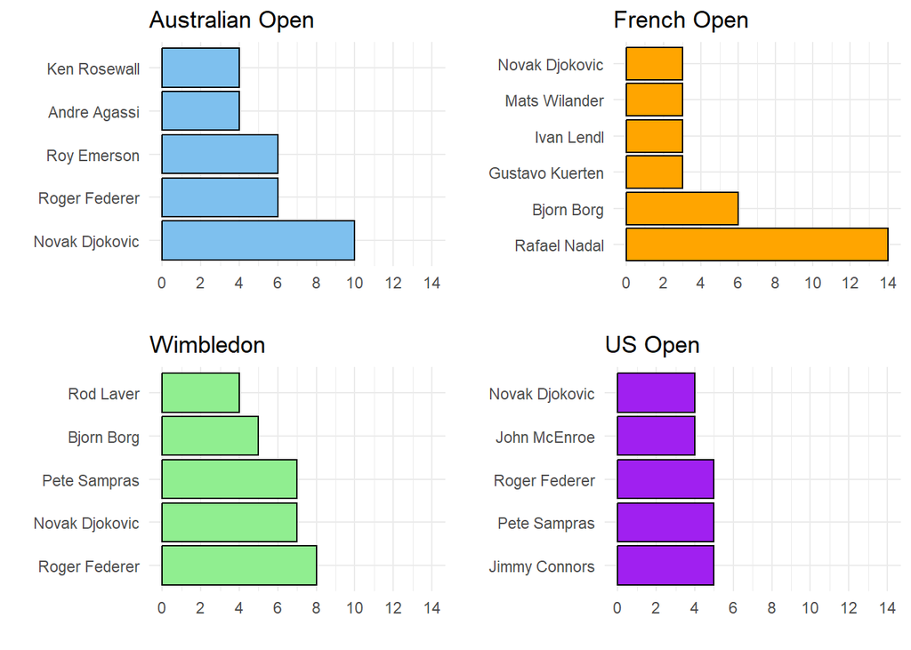

```r
top5_winners_AO <- dane %>%
  filter(TOURNAMENT == "Australian Open") %>%
  group_by(WINNER) %>%
  summarize(count = n()) %>%
  arrange(desc(count)) %>%
  head(5)
top5_winners_FO <- dane %>%
  filter(TOURNAMENT == "French Open") %>%
  group_by(WINNER) %>%
  summarize(count = n()) %>%
  arrange(desc(count)) %>%
  head(6)
top5_winners_WI <- dane %>%
  filter(TOURNAMENT == "Wimbledon") %>%
  group_by(WINNER) %>%
  summarize(count = n()) %>%
  arrange(desc(count)) %>%
  head(5)
top5_winners_UO <- dane %>%
  filter(TOURNAMENT == "U.S. Open") %>%
  group_by(WINNER) %>%
  summarize(count = n()) %>%
  arrange(desc(count)) %>%
  head(5)
AO_wykres <- ggplot(top5_winners_AO, aes(reorder(WINNER, -count), count)) +
  geom_bar(stat = "identity", colour = "black", fill = "skyblue2") +
  ylab("") +
  xlab("") +
  ggtitle("Australian Open") +
  coord_flip() +
  scale_x_discrete() +
  scale_y_continuous(limits = c(0,14), breaks = seq(0,14,2))+
  theme_minimal()
FO_wykres <- ggplot(top5_winners_FO, aes(reorder(WINNER, -count), count)) +
  geom_bar(stat = "identity", colour = "black", fill = "orange") +
  ylab("") +
  xlab("") +
  ggtitle("French Open") +
  coord_flip() +
  scale_x_discrete() +
  scale_y_continuous(limits = c(0,14), breaks = seq(0,14,2))+
  theme_minimal()
WI_wykres <- ggplot(top5_winners_WI, aes(reorder(WINNER, -count), count)) +
  geom_bar(stat = "identity", colour = "black", fill = "lightgreen") +
  ylab("") +
  xlab("") +
  ggtitle("Wimbledon") +
  coord_flip() +
  scale_x_discrete() +
  scale_y_continuous(limits = c(0,14), breaks = seq(0,14,2))+
  theme_minimal()
UO_wykres <- ggplot(top5_winners_UO, aes(reorder(WINNER, -count), count)) +
  geom_bar(stat = "identity", colour = "black", fill = "purple") +
  ylab("") +
  xlab("") +
  ggtitle("US Open") +
  coord_flip() +
  scale_x_discrete() +
  scale_y_continuous(limits = c(0,14), breaks = seq(0,14,2))+
  theme_minimal()
grid.arrange(AO_wykres, FO_wykres, WI_wykres, UO_wykres, nrow = 2, ncol = 2)
```

Jak możemy zobaczyć, w każdym turnieju wielkoszlemowym są zawodnicy, którzy zdobyli więcej niż 3 tytuły. Największą dominację można zauważyć we French Open, gdzie Rafael Nadal wygrał 14 turniejów. Natomiast w US Open nie ma jednego lidera w tej kategorii.

## 4

*Jak na przestrzeni lat Federer, Nadal i Djokovic (“BIG3”) zdobywali tytuły wielkoszlemowe?*

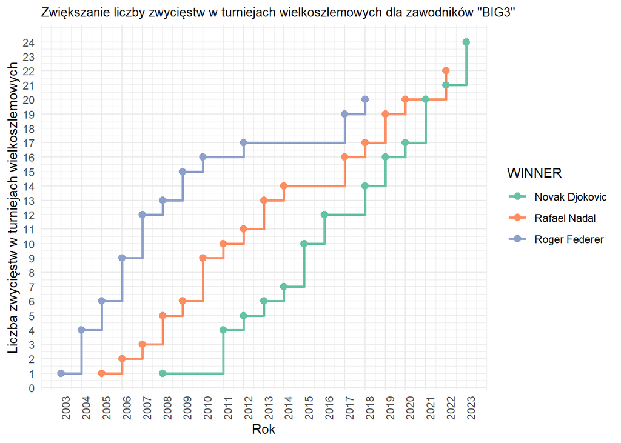

```r
zwyciezstwa_big3 <- dane %>%
  filter(WINNER %in% c("Novak Djokovic", "Rafael Nadal", "Roger Federer")) %>%
  group_by(WINNER, YEAR) %>%
  summarise(Total_Win = n()) %>%
  group_by(WINNER) %>%
  mutate(skuumulowane_wygrane = cumsum(Total_Win))
ggplot(zwyciezstwa_big3, aes(x = YEAR, y = skuumulowane_wygrane, color = WINNER)) +
  geom_step(size = 1) +
  geom_point(size = 2.5) +
  scale_color_brewer(palette = "Set2") +
  labs(x = "Rok", y = "Liczba zwycięstw w turniejach wielkoszlemowych") +
  theme_minimal() +
  ggtitle('Zwiększanie liczby zwycięstw w turniejach wielkoszlemowych dla zawodników "BIG3"') +
  theme(axis.text.x = element_text(angle = 90, hjust = 1),
        plot.title = element_text(size = 10)) +
  scale_x_continuous(breaks = seq(min(zwyciezstwa_big3$YEAR), max(zwyciezstwa_big3$YEAR), by = 1))+
  scale_y_continuous(breaks = seq(0, max(zwyciezstwa_big3$skuumulowane_wygrane), by = 1))
```

Z wykresu możemy odczytać, że Federer jako pierwszy z nich zdobył swój pierwszy tytuł wielkoszlemowy. Nie jest to zaskoczeniem, ponieważ jest najstarszy z tej trójki zawodników. W roku 2008 Federer miał już 13 tytułów, a Djokovic miał tylko jeden. Obecnie liderem pod względem ilości zwycięstw w turniejach wielkoszlemowych jest Djokovic - 24 zwycięstwa, a Federer i Nadal mają kolejno 20 i 22 tytuły.

## 5

*Jak kształtował się procentowy udział narodowości zwycięzców w turniejach wielkoszlemowych przed rokiem 2000 i po roku 2000? Czy doszło do jakichś zmian?*

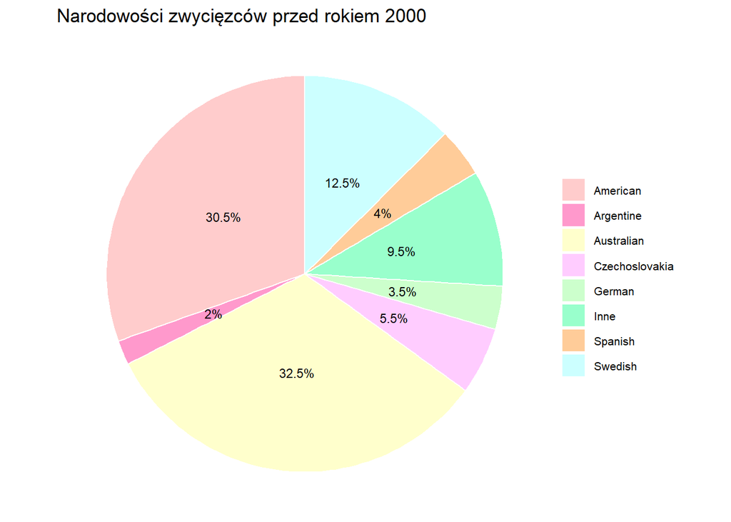

```r
kolory_narodowosci <- c(
  "American" = "#ffcccc",
  "Argentine" = "#ff99cc",
  "Australian" = "#ffffcc",
  "Czechoslovakia" = "#ffccff",
  "German" = "#ccffcc",
  "Inne" = "#99ffcc",
  "Spanish" = "#ffcc99",
  "Swedish" = "#ccffff",
  "Swiss" = "#cc99ff",
  "Serbian" = "#99ccff",
  "Russian" = "#ccff99",
  "British" = "#ccccff"
)
dane_przed_2000 <- dane %>% filter(YEAR < 2000)
liczba_zwyciestw <- dane_przed_2000 %>%
  group_by(WINNER_NATIONALITY) %>%
  summarize(count = n())
top_7 <- liczba_zwyciestw %>%
  arrange(desc(count)) %>%
  head(7)
inne <- liczba_zwyciestw %>%
  filter(!(WINNER_NATIONALITY %in% top_7$WINNER_NATIONALITY)) %>%
  summarise(WINNER_NATIONALITY = "Inne", count = sum(count))
dane_do_wykresu <- bind_rows(top_7, inne)
wykres_kolowy <- ggplot(dane_do_wykresu, aes(x = "", y = count, fill = WINNER_NATIONALITY)) +
  geom_bar(stat = "identity", width = 1, color = "white") +
  coord_polar("y") +
  theme_void() +
  labs(title = "Narodowości zwycięzców przed rokiem 2000") +
  geom_text(size = 3, aes(label = paste0(round(count / sum(count) * 100, 1), "%")), position = position_stack(vjust = 0.5)) +
  scale_fill_manual(values = kolory_narodowosci)+
  theme(legend.position = "right", legend.text = element_text(size = 8), legend.title = element_blank())

dane_po_2000 <- dane %>% filter(YEAR >= 2000)
liczba_zwyciestw1 <- dane_po_2000 %>%
  group_by(WINNER_NATIONALITY) %>%
  summarize(count = n())
top_7a <- liczba_zwyciestw1 %>%
  arrange(desc(count)) %>%
  head(7)
inne1 <- liczba_zwyciestw1 %>%
  filter(!(WINNER_NATIONALITY %in% top_7a$WINNER_NATIONALITY)) %>%
  summarise(WINNER_NATIONALITY = "Inne", count = sum(count))
dane_do_wykresu1 <- bind_rows(top_7a, inne1)

wykres_kolowy1 <- ggplot(dane_do_wykresu1, aes(x = "", y = count, fill = WINNER_NATIONALITY)) +
  geom_bar(stat = "identity", width = 1, color = "white") +
  coord_polar("y") +
  theme_void() +
  labs(title = "Narodowości zwycięzców po roku 2000") +
  geom_text(size = 3, aes(label = paste0(round(count / sum(count) * 100, 1), "%")), position = position_stack(vjust = 0.5)) +
  scale_fill_manual(values = kolory_narodowosci)+
  theme(legend.position = "right", legend.text = element_text(size = 8), legend.title = element_blank())
wykres_kolowy
```

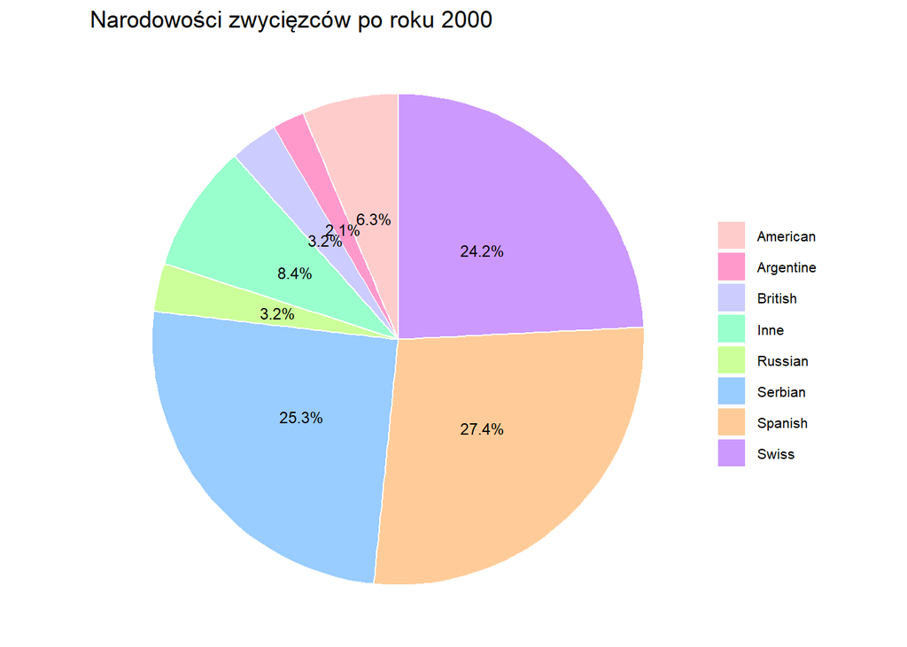

```r
wykres_kolowy1
```

Z wykresów możemy odczytać, że procentowy udział narodowości zwycięzców przed rokiem 2000 różni się od procentowego udziału narodowości zwycięzców po roku 2000. Główną przyczyną tej zmiany jest dominacja trzech zawodników - Djokovic, Nadal, Federer - w wygrywaniu wielkichszlemów. Przed rokiem 2000 dominowały dwa kraje: USA i Australia, a obecnie dominują: Serbia, Hiszpania i Szwajcaria.

## 6

*Kto oprócz “BIG3” wygrywał jeszcze turnieje wielkoszlemowe od roku 2003 (w tym roku Federer wygrał pierszego szlema)?*

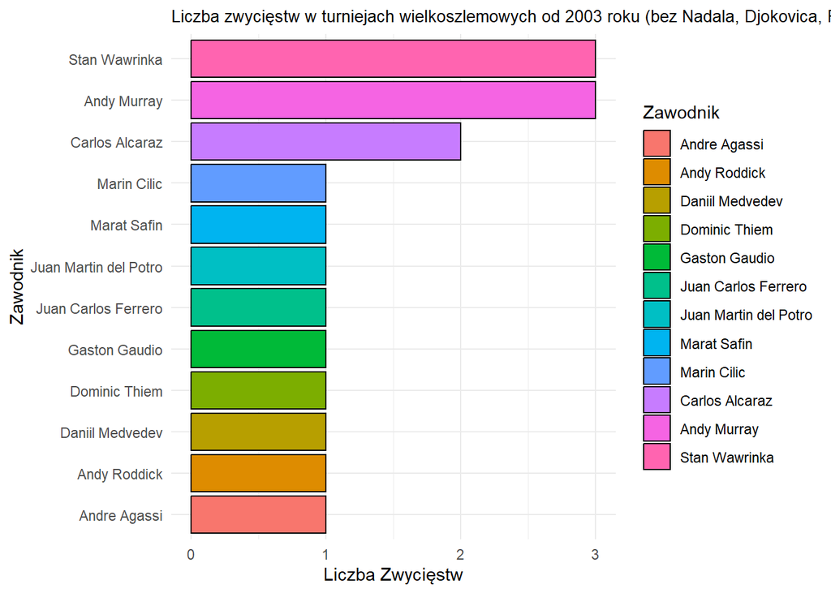

```r
dane6 <- dane[dane$YEAR > 2002, ]
dane6 <- subset(dane6, !(WINNER %in% c("Rafael Nadal", "Novak Djokovic", "Roger Federer")))
zwyciestwa <- table(dane6$WINNER)
df <- data.frame(Zawodnik = names(zwyciestwa), Ilosc_Zwyciestw = as.numeric(zwyciestwa))
df$Zawodnik <- reorder(df$Zawodnik, df$Ilosc_Zwyciestw)
ggplot(df, aes(y = Zawodnik, x = Ilosc_Zwyciestw, fill = Zawodnik)) +
  geom_bar(stat = "identity", colour = "black") +
  labs(title = "Liczba zwycięstw w turniejach wielkoszlemowych od 2003 roku (bez Nadala, Djokovica, Federera)",
       y = "Zawodnik",
       x = "Liczba Zwycięstw") +
  theme_minimal()+
  theme(#axis.text.y = element_text(angle = 45, hjust = 1),
          plot.title = element_text(size = 10))
```

Możemy zauważyć, jak bardzo “BIG3” zdominowało męski tenis od 2003 roku. Tylko 17 z 83 rozegranych turniejów zostało wygranych przez zawodnika spoza tej trójki.

## 7

*Czy istnieje zależność pomiędzy nawierzchnią kortu, a dominującą ręką zwycięzcy?*

```r
cramer_v1 <- function(dane7) {
  contingency <- table(dane7$WINNER_LEFT_OR_RIGHT_HANDED)
  cramer_v <- sqrt(chisq.test(contingency)$statistic / sum(contingency) * (min(dim(contingency)) - 1))
  return(cramer_v)
}
for (tournament in unique(dane$TOURNAMENT)) {
  dane7 <- subset(dane, TOURNAMENT == tournament)
  cramer_v <- cramer_v1(dane7)
  cat("Turniej:", tournament, "- Współczynnik V Cramera:", cramer_v, "\n")
}
```

```
## Turniej: U.S. Open - Współczynnik V Cramera: 0.4864865
## Turniej: Wimbledon - Współczynnik V Cramera: 0.6164384
## Turniej: French Open - Współczynnik V Cramera: 0.4054054
## Turniej: Australian Open - Współczynnik V Cramera: 0.7297297
```

## 8

*Czy jest jakiś zawodnik, który zdobył Klasyczny Wielki Szlem, czyli wygrał cztery turnieje wielkoszlemowe w jednym sezonie?*

```r
klasyczny_szlem <- dane %>%
    group_by(WINNER, YEAR) %>%
    filter(n_distinct(TOURNAMENT) == 4) %>%
    summarise()
klasyczny_szlem
```

```
## # A tibble: 2 × 2
## # Groups:   WINNER [1]
##   WINNER     YEAR
##   <chr>     <dbl>
## 1 Rod Laver  1962
## 2 Rod Laver  1969
```

Możemy zauważyć, że dokonano tego dwukrotnie, a uczynił to ten sam zawodnik - Rod Laver - w latach 1962 i 1969. Jest to ogromne osiągnięcie, którego nikt po 1969 roku nie powtórzył.

## 9

*Ile zarobili zawodnicy “BIG3” w poszczególnych wielkichszlemach za wygrane turnieje?*

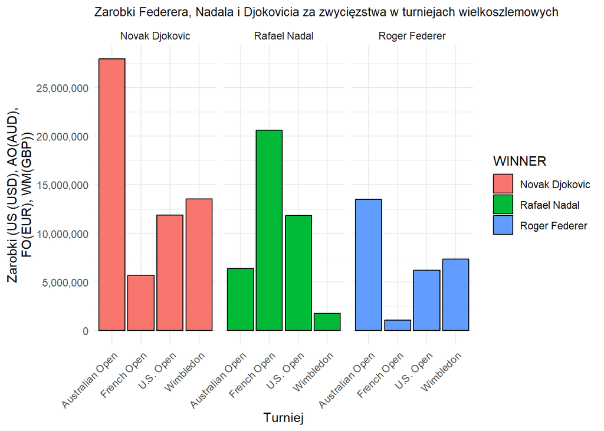

```r
selected_players <- c("Rafael Nadal", "Novak Djokovic", "Roger Federer")
data_filtered <- dane %>% filter(WINNER %in% selected_players)
summary_data <- data_filtered %>%
  group_by(WINNER, TOURNAMENT) %>%
  summarize(TOTAL_PRIZE = sum(WINNER_PRIZE))
    ggplot(summary_data, aes(x = TOURNAMENT, y = TOTAL_PRIZE, fill = WINNER)) +
    geom_bar(stat = "identity", colour = "black", position = "dodge") +
    labs(title = "Zarobki Federera, Nadala i Djokovicia za zwycięzstwa w turniejach wielkoszlemowych",
         x = "Turniej", y = "Zarobki (US (USD), AO(AUD),
FO(EUR), WM(GBP))") +
    facet_wrap(~WINNER, scales = "fixed") +
    scale_y_continuous(labels = scales::comma, breaks = seq(0, max(summary_data$TOTAL_PRIZE), by = 5000000)) +
    theme_minimal() +
    theme(axis.text.x = element_text(angle = 45, hjust = 1),
          plot.title = element_text(size = 10))
```

Tenis to dyscyplina sportowa, w której można zdobyć ogromne sumy pieniędzy. Novak Djokovic samymi zwycięstwami w Australii zarobił ponad 25 milionów dolarów australijskich. Jednak tylko nieliczni gracze osiągają takie znaczne kwoty. Jeśli tenisiści nie odnoszą sukcesów w dużych turniejach, nie mogą oczekiwać aż tak wysokich nagród finansowych.